# Trends and Variations in Emergency Department Activity Across Scottish Health Boards (2015–2023):

Boaz Baliesima Baliejukia

2024-11-24

# Introduction

The emergency department (ED) is a vital component of healthcare systems and one of the most important wards in a hospital, providing immediate clinical and paraclinical care to individuals injured in accidents and incidents (Ajami et al., 2012). The primary duty of the emergency department is to provide medical attention in high-risk situations. Seconds and minutes matter greatly for patients in the ED. These periods could determine how long it takes for someone to pass away, become seriously disabled, or survive (Ajami et al., 2012; Spechbach et al., 2019). However, one of the key components of healthcare management is the length of time patients must wait in the emergency room. This is among the variables that determine patient satisfaction and one of the metrics used to assess the quality of emergency services (Spechbach et al., 2019). In the United Kingdom, the goal for all member states is that for 95% of patients to be admitted, released, or moved from A&E departments in less than four hours. This is regarded as a safety target, supported by data showing worse outcomes after prolonged waits of more than 6–12 hours (Royal College of Emergency Medicine (RCEM), 2021).

Prior to the COVID-19 outbreak, Scottish EDs appeared to already be experiencing high patient attendance rates, leading to increased pressure on resources and staff. There were concerns about long waiting times, with many patients waiting beyond the four-hour target (RCEM, 2021). At the onset of the pandemic, there was a significant drop in ED attendances as people avoided hospitals due to fear of infection (Mulholland et al., 2020).

After lockdown measures were lifted, there was a sudden surge in ED attendances, overwhelming the system and leading to longer waiting times. Implementing COVID-19 infection control measures strained resources further, as additional space and staff were needed to manage both COVID-19 and non-COVID-19 patients. Many healthcare staff were redeployed to manage COVID-19 cases, reducing the workforce available for other emergency care (Scottish Government, 2022).

Post-COVID-19, there seems to be persistent high attendance. Indeed, attendance rates have returned to pre-pandemic levels or even higher, continuing to put pressure on EDs. Waiting times appear to have increased, with a significant number of patients waiting beyond the four-hour target, according to the RCEM (2021). Therefore, evaluating activities within EDs, including patient attendance, waiting times, and hospitalisations across the 14 Scottish health boards, offers valuable insights into healthcare performance and resource allocation. This study aims to analyse these factors across Scottish health boards over a nine-year period from 2015 to 2023, identifying trends, disparities, and potential areas for improvement.

To achieve our research objectives, we have outlined two specific aims:

- *Specific aim 1*: Evaluate trends in waiting times and patient attendance in emergency departments across Scottish Health Boards from 2015 to 2023 and their impact on overall healthcare performance and patient outcomes.
- *Specific Aim 2*: Identify variations in emergency hospitalisations across different Scottish health boards over years.

# Data handling and visualisation

## Load packages

```r
library(tidyverse)
library(viridis)      # For pretty color scales in our graphs.
library(hrbrthemes)   # For additional themes, theme components, and utilities for ggplot.
library(showtext)     # For custom fonts in our graphs.
library(grid)         # For  complex layouts in our plots
library(ggiraph)      # For custom annotations
```

## Setting up fonts

To enhance the visual appeal of our graphs, we add some custom fonts with the package “showtext”. Custom fonts are added with the function font_add(), then called with showtext_auto().

```r
font_add(family = "MarkerFelt", regular ="/Library/Fonts/MarkerFelt.ttc")
font_add(family = "AmericanTypewriter",
         regular ="/Library/Fonts/Supplemental/AmericanTypewriter.ttc")
font_add(family = "Charter",
         regular ="/Library/Fonts/Supplemental/Charter.ttc")
font_add(family = "Arial Rounded Bold",
         regular ="/Library/Fonts/Supplemental/Arial Rounded Bold.ttf")
showtext_auto()
```

## Loading data

Our datasets are loaded directly from our project folder.

The first dataset is from the Scottish Public Health Observatory (ScotPHO) website. It includes yearly emergency patient hospitalisations (Age-sex standardised rate per 100,000) registered from 2003 to 2021 in Scottish health boards (ScotPHO profiles, 2024). The name **hospitalisation** was assigned to this dataset.

The second dataset is from the Public Health Scotland NHS Performs website, providing weekly updates on emergency department activity and waiting time statistics from 2015 to 2023 (Public Health Scotland, 2023). The name **performs** was assigned to this one.

The data is saved in csv files, so we will use the read.csv() function.

```r
hospitalisation <- read_csv("ScotPHO.csv")
performs <- read_csv("NHS Performs.csv")
```

## Data inspection

We will inspect data with head(), glimpse() and summary() functions to get an idea of the data we are dealing with.

```r
head(performs, 5)
```

```
## # A tibble: 5 × 12
##   week_ending_date nhs_board_cypher nhs_board_name   location_code location_name
##   <date>           <chr>            <chr>            <chr>         <chr>
## 1 2015-02-22       A                NHS Ayrshire & … A             NHS Ayrshire…
## 2 2015-02-22       B                NHS Borders      B             NHS Borders
## 3 2015-02-22       Y                NHS Dumfries & … Y             NHS Dumfries…
## 4 2015-02-22       F                NHS Fife         F             NHS Fife
## 5 2015-02-22       V                NHS Forth Valley V             NHS Forth Va…
## # ℹ 7 more variables: attendance <dbl>, number_over_4_hours <dbl>,
## #   percentage_within_4_hours <dbl>, number_over_8_hours <dbl>,
## #   percentage_within_8_hours <dbl>, number_over_12_hours <dbl>,
## #   percentage_within_12_hours <dbl>
```

```r
glimpse(performs)
```

```
## Rows: 5,992
## Columns: 12
## $ week_ending_date           <date> 2015-02-22, 2015-02-22, 2015-02-22, 2015-0…
## $ nhs_board_cypher           <chr> "A", "B", "Y", "F", "V", "N", "G", "H", "L"…
## $ nhs_board_name             <chr> "NHS Ayrshire & Arran", "NHS Borders", "NHS…
## $ location_code              <chr> "A", "B", "Y", "F", "V", "N", "G", "H", "L"…
## $ location_name              <chr> "NHS Ayrshire & Arran", "NHS Borders", "NHS…
## $ attendance                 <dbl> 2161, 517, 800, 1284, 1095, 1877, 7579, 950…
## $ number_over_4_hours        <dbl> 422, 54, 37, 149, 42, 196, 1823, 47, 524, 2…
## $ percentage_within_4_hours  <dbl> 80.5, 89.6, 95.4, 88.4, 96.2, 89.6, 75.9, 9…
## $ number_over_8_hours        <dbl> 52, 1, 1, 22, 0, 38, 463, 1, 120, 34, 0, 0,…
## $ percentage_within_8_hours  <dbl> 97.6, 99.8, 99.9, 98.3, 100.0, 98.0, 93.9, …
## $ number_over_12_hours       <dbl> 4, 0, 0, 7, 0, 4, 127, 0, 45, 0, 0, 0, 0, 0…
## $ percentage_within_12_hours <dbl> 99.8, 100.0, 100.0, 99.5, 100.0, 99.8, 98.3…
```

```r
summary(performs)
```

```
##  week_ending_date     nhs_board_cypher   nhs_board_name     location_code
##  Min.   :2015-02-22   Length:5992        Length:5992        Length:5992
##  1st Qu.:2017-03-10   Class :character   Class :character   Class :character
##  Median :2019-03-27   Mode  :character   Mode  :character   Mode  :character
##  Mean   :2019-03-27
##  3rd Qu.:2021-04-12
##  Max.   :2023-04-30
##  location_name        attendance     number_over_4_hours
##  Length:5992        Min.   :  38.0   Min.   :   0.00
##  Class :character   1st Qu.: 557.8   1st Qu.:  22.75
##  Mode  :character   Median :1230.0   Median :  97.00
##                     Mean   :1784.7   Mean   : 256.35
##                     3rd Qu.:2103.2   3rd Qu.: 283.25
##                     Max.   :7843.0   Max.   :3667.00
##  percentage_within_4_hours number_over_8_hours percentage_within_8_hours
##  Min.   : 37.20            Min.   :   0.00     Min.   : 65.50
##  1st Qu.: 86.00            1st Qu.:   0.00     1st Qu.: 98.30
##  Median : 92.80            Median :   5.00     Median : 99.60
##  Mean   : 88.85            Mean   :  50.65     Mean   : 97.86
##  3rd Qu.: 96.20            3rd Qu.:  37.00     3rd Qu.:100.00
##  Max.   :100.00            Max.   :1421.00     Max.   :100.00
##  number_over_12_hours percentage_within_12_hours
##  Min.   :  0.00       Min.   : 79.80
##  1st Qu.:  0.00       1st Qu.: 99.70
##  Median :  0.00       Median :100.00
##  Mean   : 17.01       Mean   : 99.21
##  3rd Qu.:  5.00       3rd Qu.:100.00
##  Max.   :670.00       Max.   :100.00
```

```r
head(hospitalisation, 5)
```

```
## # A tibble: 5 × 11
##   area_code area_type area_name  year period type_definition indicator numerator
##   <chr>     <chr>     <chr>     <dbl> <chr>  <chr>           <chr>         <dbl>
## 1 S08000015 Health b… NHS Ayrs…  2003 2002 … Age-sex standa… Emergenc…    27042
## 2 S08000016 Health b… NHS Bord…  2003 2002 … Age-sex standa… Emergenc…     7888
## 3 S08000017 Health b… NHS Dumf…  2003 2002 … Age-sex standa… Emergenc…     9264
## 4 S08000019 Health b… NHS Fort…  2003 2002 … Age-sex standa… Emergenc…    17917.
## 5 S08000020 Health b… NHS Gram…  2003 2002 … Age-sex standa… Emergenc…    33842.
## # ℹ 3 more variables: measure <dbl>, upper_confidence_interval <dbl>,
## #   lower_confidence_interval <dbl>
```

```r
glimpse(hospitalisation)
```

```
## Rows: 266
## Columns: 11
## $ area_code                 <chr> "S08000015", "S08000016", "S08000017", "S080…
## $ area_type                 <chr> "Health board", "Health board", "Health boar…
## $ area_name                 <chr> "NHS Ayrshire & Arran", "NHS Borders", "NHS …
## $ year                      <dbl> 2003, 2003, 2003, 2003, 2003, 2003, 2003, 20…
## $ period                    <chr> "2002 to 2004 calendar years; 3-year aggrega…
## $ type_definition           <chr> "Age-sex standardised rate per 100,000", "Ag…
## $ indicator                 <chr> "Emergency patient hospitalisations", "Emerg…
## $ numerator                 <dbl> 27042.0, 7888.0, 9264.0, 17917.3, 33841.7, 2…
## $ measure                   <dbl> 7768.3, 7458.3, 6381.6, 6965.0, 7005.0, 7334…
## $ upper_confidence_interval <dbl> 7865.3, 7630.5, 6516.9, 7073.1, 7083.7, 7437…
## $ lower_confidence_interval <dbl> 7672.1, 7288.9, 6248.3, 6858.0, 6927.0, 7232…
```

```r
summary(hospitalisation)
```

```
##   area_code          area_type          area_name              year
##  Length:266         Length:266         Length:266         Min.   :2003
##  Class :character   Class :character   Class :character   1st Qu.:2007
##  Mode  :character   Mode  :character   Mode  :character   Median :2012
##                                                           Mean   :2012
##                                                           3rd Qu.:2017
##                                                           Max.   :2021
##     period          type_definition     indicator           numerator
##  Length:266         Length:266         Length:266         Min.   : 1201
##  Class :character   Class :character   Class :character   1st Qu.: 8922
##  Mode  :character   Mode  :character   Mode  :character   Median :23629
##                                                           Mean   :27027
##                                                           3rd Qu.:35071
##                                                           Max.   :96596
##     measure      upper_confidence_interval lower_confidence_interval
##  Min.   : 5352   Min.   : 5666             Min.   :5050
##  1st Qu.: 6668   1st Qu.: 6845             1st Qu.:6537
##  Median : 7053   Median : 7190             Median :6937
##  Mean   : 7238   Mean   : 7387             Mean   :7094
##  3rd Qu.: 7894   3rd Qu.: 8038             3rd Qu.:7753
##  Max.   :10051   Max.   :10154             Max.   :9948
```

Both datasets seem to be clean, with no missing data. However, we just noticed that the time is in a full date format in the dataset called performs while it is in year in the one called hospitalisation. We can then go to the next steps.

## Data visualisation

#### Specific aim 1: Evaluate trends in waiting times and patient attendance in emergency departments across Scottish Health Boards from 2015 to 2023 and their impact on overall healthcare performance and patient outcomes.

Bar graph of waiting time (4 hours) in 2023

Let’s plot a bar chart showing the Emergency Department attendances that were seen and resulted in a subsequent admission, transfer or discharge within 4 hours in 2023.

We will first create a summary table called **median_waiting** with the median of the column *percentage_within_4_hours* for each NHS_board in 2023 from the “performs” dataset. Then, we will plot a bar chart that includes a vertical line indicating the **national standard** for Accident & Emergency (A&E) services in the UK, which has been set at **95%** since 2007. This standard means that 95% of patients should wait no longer than 4 hours from their arrival to either admission, discharge, or transfer in A&E (Public Health Scotland, 2023).

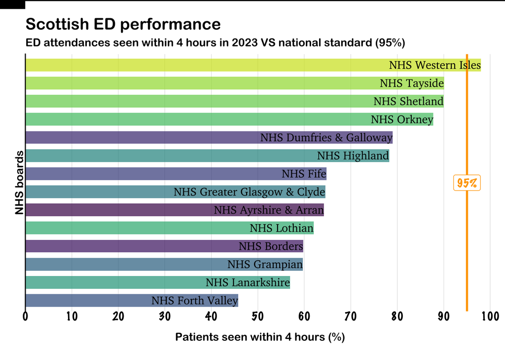

```r
# compute median of percentage_within_4_hours first
median_waiting <- performs %>%
  filter(format(week_ending_date, "%Y") == "2023") %>%
  group_by(nhs_board_name) %>%
  summarise(median = median(percentage_within_4_hours))

# Let's plot a bar graph
bar_waiting <- median_waiting %>%
  ggplot(aes(reorder(nhs_board_name, median), median, fill = nhs_board_name)) +
  geom_col(width = 0.7 , alpha = 0.7) +
  scale_fill_manual(values = viridis(15)) +
  geom_hline_interactive(aes(yintercept = 95), color = "orange", size = 1) +
  coord_flip() +

# let's customize layout now
  theme_classic() +

  labs(x = "NHS boards",
         y = "Patients seen within 4 hours (%)",
         title = "Scottish ED performance",
         subtitle = "ED attendances seen within 4 hours in 2023 VS national standard (95%)") +

  theme(legend.position = "none",
        axis.title.x = element_text(margin = margin(t = 10)),
        axis.title.y = element_text(margin = margin(t = 20)),
        plot.title = element_text(family = "Arial Rounded Bold",
                                  face = "bold",
                                  size = 16),
        plot.subtitle = element_text(family = "Arial Rounded Bold",
                                     size = 11),
        panel.grid.major.x = element_line(color = "gray", linewidth = 0.1),
        text = element_text(family = "Arial Rounded Bold"),
        axis.line.x.bottom = element_blank(),
        axis.ticks.length = unit(0, "mm"),
        axis.text.y = element_blank(),
        axis.text.x = element_text(size = 11,
                                   family = "MarkerFelt",
                                   margin = margin(r = 10))) +

  scale_y_continuous(expand = c(0, 0),
                       limits = c(0, 101),
                       breaks = seq(0, 100, by = 10)) +

  geom_text(aes(nhs_board_name, label = nhs_board_name),
              hjust = 1,
              family = "Charter",
              size = 4) +

# We are now adding up some annotations
  annotate(geom = "label",
           x = 7.5,
           y = 95,
           label = "95%",
           family = "MarkerFelt", colour = "orange") +

  theme(plot.margin = margin(0.05, 0.02, 0.05, 0.03, "npc")) # specifies the margins around the plot
bar_waiting

# Let's add a black line at the top of the graph to make it look cool.
grid.lines(x = c(0, 4), y = 1,
           gp = gpar(col = "black", lwd = 3))
grid.rect(x = 0, y = 1, width = 0.05, height = 0.025,
          just = c("left", "top"), gp = gpar(fill = "black", lwd = 0))
```

In the previous graph, it can be observed that only the **NHS Western Isles** health board achieved the goal of 95% of patients being seen within 4 hours, while **NHS Forth Valley** failed to reach even 50%.

Next, let’s create a line graph to illustrate the trend of emergency department (ED) attendances over the years from 2015 to 2023 for both the *NHS Western Isles* and *NHS Forth Valley* health boards.

[figure not shown]

```r
BLUE <- "#076fa2"
GREEN <- "#01796F" # Define the colors we will be using.

line.graph <- performs %>%
  filter(nhs_board_name %in% c("NHS Western Isles", "NHS Forth Valley")) %>%
  group_by(nhs_board_name, week_ending_date) %>%
  ggplot(aes(week_ending_date, attendance, color = nhs_board_name)) +
  geom_line() +
  scale_color_manual(values = c(BLUE, GREEN)) +

# let's customise the layout now
  theme_classic() +
  labs(title = "NHS Western Isles vs NHS Forth Valley",
       subtitle = "Weekly ED attendances from 2015 to 2023",
       x = "Time (years)",
       y = "Weekly attendances") +
  theme(text = element_text(family = "Arial Rounded Bold"),
        legend.position = "none",
        panel.grid.major.x = element_line(color = "gray", linewidth  = 0.1, linetype = "dashed"),
        panel.grid.major.y = element_line(color = "gray", linewidth  = 0.1, linetype = "dashed"),
        plot.title = element_text(face = "bold",
                                  size = 16, color = "red"),
        plot.subtitle = element_text(size = 11),

        axis.title.x = element_text(margin = margin(t = 10)),
        axis.title.y = element_text(margin = margin(t = 20)),
        axis.text.x = element_text(size = 11, family = "MarkerFelt", margin = margin(r = 1)),
        axis.text.y = element_text(size = 11, family = "MarkerFelt", margin = margin(r = 1)),
        scale_y_continuous(expand = c(0, 0),
                       limits = c(0, 203),
                       breaks = seq(0, 200, by = 25)),
        axis.line = element_line(arrow = arrow(length = unit(0.2, "cm"), type = "closed" ))) +

# We are now adding up some annotations
  annotate(geom = "rect",
           xmin = as.Date("2020-03-01"), xmax = as.Date("2021-01-31"),
                 ymin = 0, ymax = 1500,
                 fill = "white", alpha = 0.1,
           colour = "black") +
  annotate(geom = "text",
           x = as.Date("2020-11-01"),
           y = 1550,
           label = "Lockdown Mar20-Jan21",
           family = "MarkerFelt") +
  annotate(geom = "label",
           x = as.Date("2017-01-01"),
           y = 925,
           label = "NHS Western Isles",
           family = "MarkerFelt",
           colour = BLUE) +
  annotate(geom = "label",
           x = as.Date("2017-01-01"),
           y = 300,
           label = "NHS Forth Valley",
           family = "MarkerFelt",
           colour = GREEN) +
  theme(plot.margin = margin(0.05, 0.02, 0.05, 0.03, "npc")) # specifies the margins around the plot

line.graph

# Let's add a black line at the top of the graph to make it look cool.
grid.lines(x = c(0, 4), y = 1,
           gp = gpar(col = "black", lwd = 3))
grid.rect(x = 0, y = 1, width = 0.05, height = 0.025,
          just = c("left", "top"), gp = gpar(fill = "black", lwd = 0))
```

## Specific Aim 2: Identify variations in emergency hospitalisations across different Scottish health boards over years.

**We are comparing emergency hospitalisations across all Scottish health boards in 2015 and 2021.**

First, let’s calculate the average emergency hospitalisations for each Scottish NHS board from the **hospitalisation** dataset annually and create a summary table called *mean_hosp*.

```r
mean_hosp <- hospitalisation %>%
    group_by(year, area_name) %>%
    summarise(mean_hospitalisation = mean(measure))

mean_hosp %>% head()
```

```
## # A tibble: 6 × 3
## # Groups:   year [1]
##    year area_name               mean_hospitalisation
##   <dbl> <chr>                                  <dbl>
## 1  2003 NHS Ayrshire & Arran                   7768.
## 2  2003 NHS Borders                            7458.
## 3  2003 NHS Dumfries & Galloway                6382.
## 4  2003 NHS Fife                               6836.
## 5  2003 NHS Forth Valley                       6965
## 6  2003 NHS Grampian                           7005
```

Let’s plot a bar chart comparing ED hospitalisation in 2015 and 2021 across Scottish Health Boards and call it *bar_hosp*.

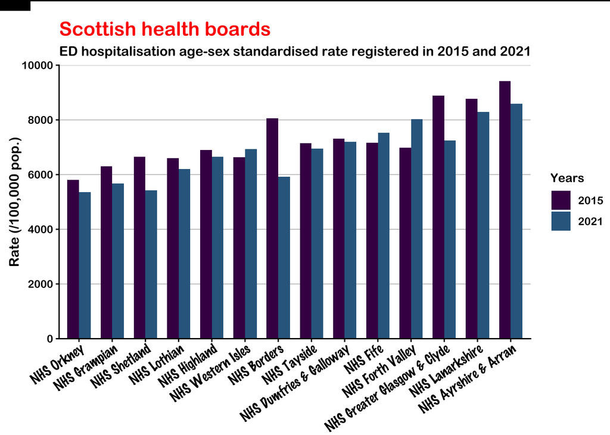

```r
bar_hosp <- mean_hosp %>%
  filter(year %in% c(2015, 2021)) %>%
  ggplot(aes(reorder(area_name, mean_hospitalisation), mean_hospitalisation, fill = as.factor(year))) +
  geom_bar(stat = "identity", position = "dodge", width = 0.7) +
  scale_fill_manual(values = viridis(4)) +

# let's customise the layout now
  theme_classic() +
  labs(y = "Rate (/100,000 pop.)",
       title = "Scottish health boards",
       subtitle = "ED hospitalisation age-sex standardised rate registered in 2015 and 2021",
       fill = "Years") +
  xlab(element_blank()) +
  theme(legend.position = "right",
        legend.title = element_text(size = 10, face = "bold"),
        axis.text.x = element_text(angle = 34, hjust = 1,       #rotate group names
                                   size = 11,
                                   family = "MarkerFelt",
                                   margin = margin(r = 10)),
        axis.title.x = element_text(margin = margin(t = 10)),
        axis.title.y = element_text(margin = margin(t = 20)),
        plot.title = element_text(family = "Arial Rounded Bold",
                                  face = "bold",
                                  size = 16, colour = "red"),
        plot.subtitle = element_text(family = "Arial Rounded Bold",
                                     size = 11),
        panel.grid.major.y = element_line(color = "gray",
                                          linewidth = 0.3),
        text = element_text(family = "Arial Rounded Bold"),
        plot.margin = margin(0.05, 0, 0, 0.015, "npc")) +   # specifies the margins around the plot

  scale_y_continuous(expand = c(0, 0),
                       limits = c(0, 10000),
                       breaks = seq(0, 10000, by = 2000))   # Set y-axis scale

bar_hosp
# Let's add a black line at the top of the graph to make it look cool.
grid.lines(x = c(0, 4),
           y = 1,
           gp = gpar(col = "black",
                     lwd = 3))
grid.rect(x = 0, y = 1, width = 0.05, height = 0.025,
          just = c("left", "top"), gp = gpar(fill = "black", lwd = 0))
```

# Summary

Our target audience includes Public Health officers, hospital managers, and emergency department heads. These stakeholders can utilise the data to enhance patient flow, reduce waiting times, and improve overall hospital efficiency. Additionally, Public Health officers can analyse the data to identify trends, find areas needing improvement in ED organisation, and develop strategies to address public health challenges.

The primary objective of our graphs is to illustrate the performance of Emergency Departments in NHS Scotland health boards relative to the national standard, which mandates that 95% of patients should wait no longer than 4 hours from arrival to admission, discharge, or transfer for A&E treatment (Public Health Scotland, 2023).

To create our visualisations, we utilised two datasets:

- Scottish Public Health Observatory (ScotPHO) Dataset: This dataset includes yearly emergency patient hospitalisations from 2003 to 2021 across Scottish health boards. It was selected by choosing ‘health board’ as the dataset type, ‘health and well-being’ as the profile, and ‘emergency patient hospitalisations’ as the indicator, covering all years of interest (ScotPHO profiles, 2024).
- Public Health Scotland Dataset: This dataset provides weekly updates on emergency department activity and waiting time statistics from 2015 to 2023 (Public Health Scotland, 2023).

**Data limitations**

- The datasets originate from two different organisations, potentially leading to variations in data collection methods.
- The NHS Performs dataset collects data weekly from 2015 to 2023, whereas the ScotPHO dataset provides yearly data, presented as a 3-year rolling average and age-sex standardised rate per 100,000 population.
- The data is not at the population level, making individual-level conclusions challenging.

# References

Ajami, S. et al. (2012) ‘Wait Time in Emergency Department (ED) Processes’, 66(1), pp. 53–57. Available at: https://doi.org/10.5455/medarh.2012.66.53-57.

Mulholland, R.H. et al. (2020) ‘Impact of COVID-19 on accident and emergency attendances and emergency and planned hospital admissions in Scotland: an interrupted time-series analysis’, Journal of the Royal Society of Medicine, 113(11), pp. 444–453. Available at: https://doi.org/10.1177/0141076820962447.

Public Health Scotland (2023) NHS Performs - weekly update of emergency department activity and waiting time statistics. Available at: https://publichealthscotland.scot/publications/nhs-performs-weekly-update-of-emergency-department-activity-and-waiting-time-statistics/nhs-performs-weekly-update-of-emergency-department-activity-and-waiting-time-statistics-week-ending-30-april-2023/ (Accessed: 21 October 2024).

RCEM (2021) Emergency Departments in Scotland experience worst ever May performance. Available at: https://rcem.ac.uk/rcem-we-have-a-serious-problem-in-urgent-emergency-care/ (Accessed: 21 October 2024).

Royal College of Emergency Medicine (2021) ‘Delayed hospital handovers: Impact assessment of patient harm’. ScotPHO profiles (2024). Available at: https://scotland.shinyapps.io/ScotPHO_profiles_tool/ (Accessed: 21 October 2024).

Scottish Government (2022) Coronavirus (COVID-19) Scotland’s Strategic Framework update – February 2022: evidence paper. Available at: https://www.gov.scot/publications/evidence-paper-accompany-coronavirus-covid-19-scotlands-strategic-framework-update-february-2022/pages/3/ (Accessed: 21 October 2024).

Spechbach, H. et al. (2019) ‘Patients’ time perception in the waiting room of an ambulatory emergency unit: a cross-sectional study’, BMC Emergency Medicine, 19(1), p. 41. Available at: https://doi.org/10.1186/S12873-019-0254-1.